###Download the training set: Connect to the opendatasoft website and download the random sample of 891 Titanic Passengers. This is the training set. The data come in JSON form format and you can use this URL to access the data: #https://public.opendatasoft.com/api/records/1.0/search/?dataset=titanic-passengers&rows=2000&facet=survived&facet=pclass&facet=sex&facet=age&facet=embarked #Hint: This is not trivial. I recommend that you use the jsonlite package (fromJSON()) and RCurl package (getURL()) to access the data. (We covered this in Unit 4).  
#Try your best to access the data using the URL. You may also find the data (titanic_train.csv) on github. We will go over this data ingestion in live session.

```r
library(XML) #xml_Parse
library(dplyr)
```

```r
library(tidyr)
library(stringi)
library(rvest) #html_table, html_node
library(ggplot2)
library(RCurl) #getURL
library(class)
library(caret)
library(e1071)

#Basics of Scraping XML

# Method 1: XML

data <-getURL("https://public.opendatasoft.com/api/records/1.0/search/?dataset=titanic-passengers&rows=2000&facet=survived&facet=pclass&facet=sex&facet=age&facet=embarked")
#{
#  "error": "Unknown dataset: titanic-passengers"
#}
hello1 = read.csv("titanic_train.csv")
head(hello1)
```

```
##   PassengerId Survived Pclass
## 1           1        0      3
## 2           2        1      1
## 3           3        1      3
## 4           4        1      1
## 5           5        0      3
## 6           6        0      3
##                                                  Name    Sex Age SibSp Parch
## 1                             Braund, Mr. Owen Harris   male  22     1     0
## 2 Cumings, Mrs. John Bradley (Florence Briggs Thayer) female  38     1     0
## 3                              Heikkinen, Miss. Laina female  26     0     0
## 4        Futrelle, Mrs. Jacques Heath (Lily May Peel) female  35     1     0
## 5                            Allen, Mr. William Henry   male  35     0     0
## 6                                    Moran, Mr. James   male  NA     0     0
##             Ticket    Fare Cabin Embarked
## 1        A/5 21171  7.2500              S
## 2         PC 17599 71.2833   C85        C
## 3 STON/O2. 3101282  7.9250              S
## 4           113803 53.1000  C123        S
## 5           373450  8.0500              S
## 6           330877  8.4583              Q
```

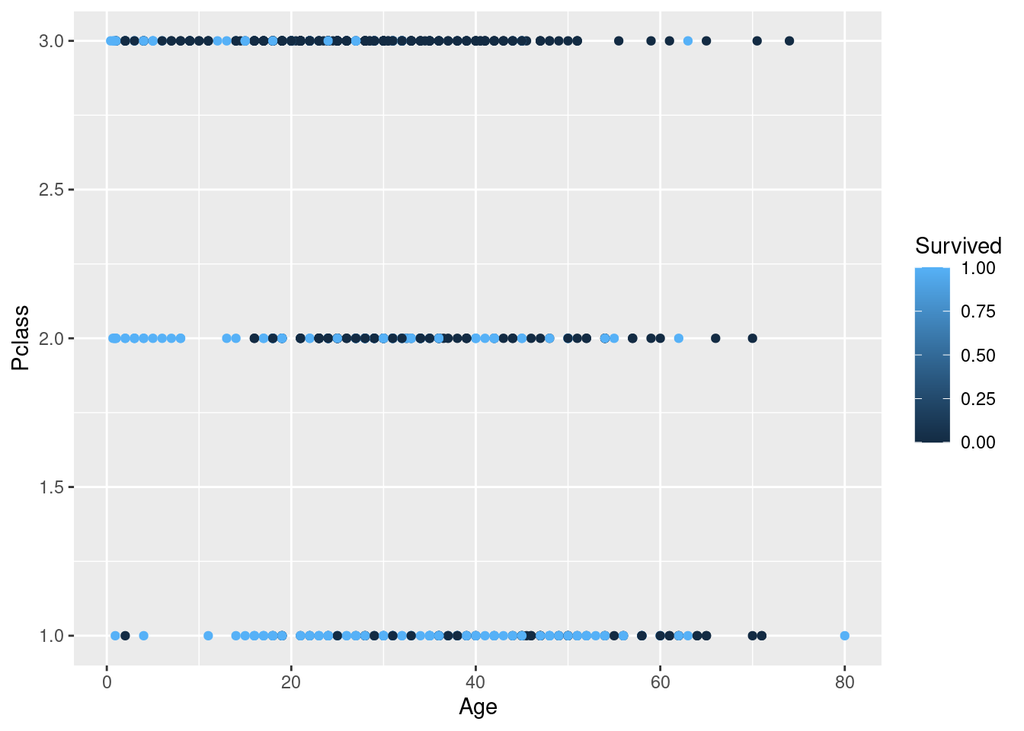

```r
hello1 %>% ggplot(aes(x = Age, y = Pclass, color = Survived)) + geom_point()
```

```r
dfTest = data.frame(Age = 40, Pclass = 2)
knn(hello1[,1:2], dfTest, hello1$Survived, k = 5, prob = TRUE)
```

```
## [1] 0
## attr(,"prob")
## [1] 0.8
## Levels: 0 1
```

```r
dfTest = data.frame(Age = 30, Pclass = 2)
knn(hello1[,1:2], dfTest, hello1$Survived, k = 15, prob = TRUE)
```

```
## [1] 0
## attr(,"prob")
## [1] 0.5333333
## Levels: 0 1
```

###Use your model to classify the 418 randomly selected passengers in the test set (titanic_test.csv) on github

```r
hello2 = read.csv("titanic_test.csv")
head(hello2)
```

```
##   PassengerId Pclass                                         Name    Sex  Age
## 1         892      3                             Kelly, Mr. James   male 34.5
## 2         893      3             Wilkes, Mrs. James (Ellen Needs) female 47.0
## 3         894      2                    Myles, Mr. Thomas Francis   male 62.0
## 4         895      3                             Wirz, Mr. Albert   male 27.0
## 5         896      3 Hirvonen, Mrs. Alexander (Helga E Lindqvist) female 22.0
## 6         897      3                   Svensson, Mr. Johan Cervin   male 14.0
##   SibSp Parch  Ticket    Fare Cabin Embarked
## 1     0     0  330911  7.8292              Q
## 2     1     0  363272  7.0000              S
## 3     0     0  240276  9.6875              Q
## 4     0     0  315154  8.6625              S
## 5     1     1 3101298 12.2875              S
## 6     0     0    7538  9.2250              S
```

```r
dfTest2 = data.frame(Age = 30, Pclass = 2)
classifications = knn(hello1[,c(1,2)],hello2[,c(1,2)],hello1$Survived, prob = TRUE, k = 3)
```

##Create a confusion matrix and calculate the accuracy, misclassification rate, sensitivity and specificity. Be prepared to explain these statistics. (It is ok if you have questions here… we will answer them in live session … just do your best in the time allotted.)

```r
#confusion matrix
classifications = knn(hello1[,c(1,2)],hello2[,c(1,2)],hello1$Survived, prob = TRUE, k = 5)
hello3=table(hello1$Survived[1:418],classifications)
hello3
```

```
##    classifications
##       0   1
##   0 255   0
##   1 163   0
```

```r
confusionMatrix(table(hello1$Survived[1:418],classifications))
```

```
## Confusion Matrix and Statistics
##
##    classifications
##       0   1
##   0 255   0
##   1 163   0
##
##                Accuracy : 0.61
##                  95% CI : (0.5614, 0.6571)
##     No Information Rate : 1
##     P-Value [Acc > NIR] : 1
##
##                   Kappa : 0
##
##  Mcnemar's Test P-Value : <2e-16
##
##             Sensitivity : 0.61
##             Specificity :   NA
##          Pos Pred Value :   NA
##          Neg Pred Value :   NA
##              Prevalence : 1.00
##          Detection Rate : 0.61
##    Detection Prevalence : 0.61
##       Balanced Accuracy :   NA
##
##        'Positive' Class : 0
##
```

#For Live Session

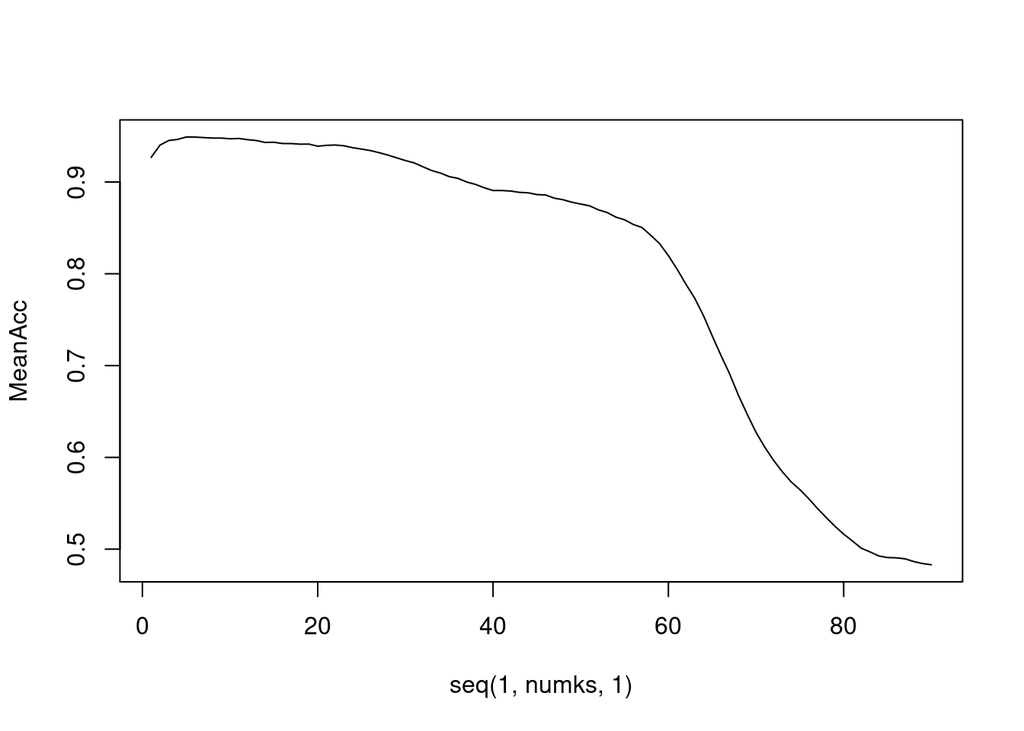

```r
#Use a 70 - 30 train/test split to use cross validation to
#tune the hyperparameter k


# Loop for many k and the average of many training / test partition

set.seed(1)
iterations = 500
numks = 90
splitPerc = .70

masterAcc = matrix(nrow = iterations, ncol = numks)

for(j in 1:iterations)
{
  trainIndices = sample(1:dim(iris)[1],round(splitPerc * dim(iris)[1]))
  train = iris[trainIndices,]
  test = iris[-trainIndices,]
  for(i in 1:numks)
  {
    classifications = knn(train[,c(1,3)],test[,c(1,3)],train$Species, prob = TRUE, k = i)
    table(classifications,test$Species)
    CM = confusionMatrix(table(classifications,test$Species))
    masterAcc[j,i] = CM$overall[1]
  }

}

MeanAcc = colMeans(masterAcc)

plot(seq(1,numks,1),MeanAcc, type = "l")
```

```r
which.max(MeanAcc)
```

```
## [1] 5
```

```r
max(MeanAcc)
```

```
## [1] 0.9490222
```

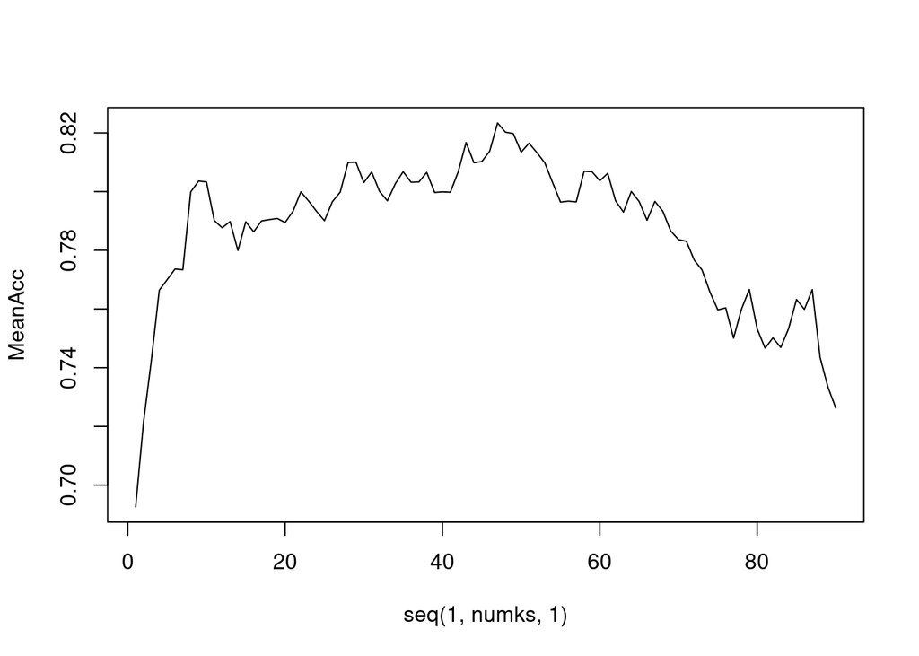

```r
# FOR LIVE SESSION LEAVE 1 OUT KNN IRIS

set.seed(1)
iterations = 500
numks = 90

masterAcc = matrix(nrow = iterations, ncol = numks)

for(j in 1:iterations)
{

  for(i in 1:numks)
  {
    CM = confusionMatrix(table(iris[,5],knn.cv(iris[,c(1,2)],iris[,5],k = i)))
    masterAcc[j,i] = CM$overall[1]

  }

}

MeanAcc = colMeans(masterAcc)

plot(seq(1,numks,1),MeanAcc, type = "l")
```

```r
which.max(MeanAcc)
```

```
## [1] 47
```

```r
max(MeanAcc)
```

```
## [1] 0.8233867
```